# Home assignment 02: Data analysis Task 4

This is the second Almaz Murzabekov’s home assignment of Data analysis task: 4

### 4. Assignment on Correspondence Analysis

Tarvel Review Ratings Dataset: https://archive.ics.uci.edu/ml/datasets/Tarvel+Review+Ratings

- Attribute 1 : Unique user id
- Attribute 2 : Average ratings on churches
- Attribute 3 : Average ratings on resorts
- Attribute 4 : Average ratings on beaches
- Attribute 5 : Average ratings on parks
- Attribute 6 : Average ratings on theatres
- Attribute 7 : Average ratings on museums
2. Use FactoMineR package to:

```r
data =
  as.data.frame(
    read.table("data/t4/google_review_ratings.csv", header = TRUE, sep = ",")
  )

head(data)
```

|  | User | Category.1 | Category.2 | Category.3 | Category.4 | Category.5 | Category.6 | Category.7 |
| --- | --- | --- | --- | --- | --- | --- | --- | --- |
| 1 | User 1 | 0.0 | 0.0 | 3.63 | 3.65 | 5 | 2.92 | 5 |
| 2 | User 2 | 0.0 | 0.0 | 3.63 | 3.65 | 5 | 2.92 | 5 |
| 3 | User 3 | 0.1 | 0.0 | 3.63 | 3.63 | 5 | 2.92 | 5 |
| 4 | User 4 | 0.0 | 0.5 | 3.63 | 3.63 | 5 | 2.92 | 5 |
| 5 | User 5 | 3.2 | 0.0 | 3.63 | 3.63 | 5 | 2.92 | 5 |
| 6 | User 6 | 0.0 | 0.0 | 3.63 | 3.63 | 5 | 2.92 | 5 |

##### (a) Do the χ2 test for independence and interpret it, see Section 2.2.2 of [4].

```r
chisq.test(data[, 2:7])
```

```
Chi-squared approximation may be incorrect
```

```
    Pearson's Chi-squared test

data:  data[, 2:7]
X-squared = 95.636, df = 120, p-value = 0.9505
```

Chi-square test results shows us that we cannot reject the null hypothesis. Null hypothesis tells us that there are not any statistically dependence between components of dataset.

##### (b) Perform the CA, get the 2D representation of row and column profiles See p.87 of [4]

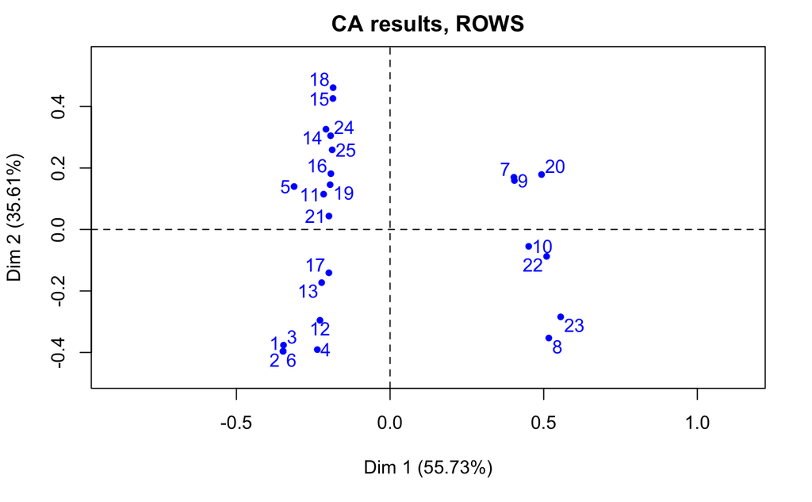

```r
ca_result = CA(data[, 2:7], graph = FALSE)
plot(ca_result, invisible = "col", title = "CA results, ROWS")
```

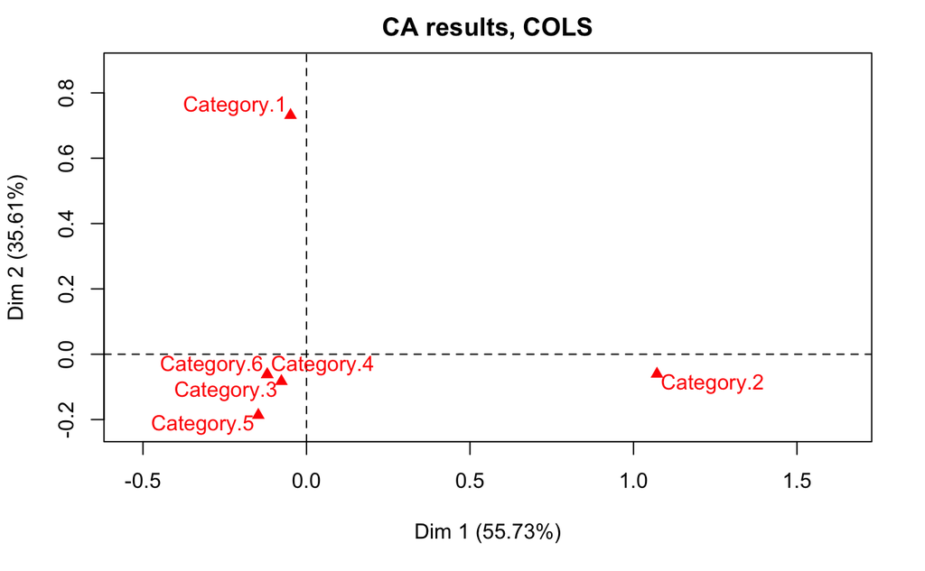

```r
plot(ca_result, invisible = "row", title = "CA results, COLS")
```

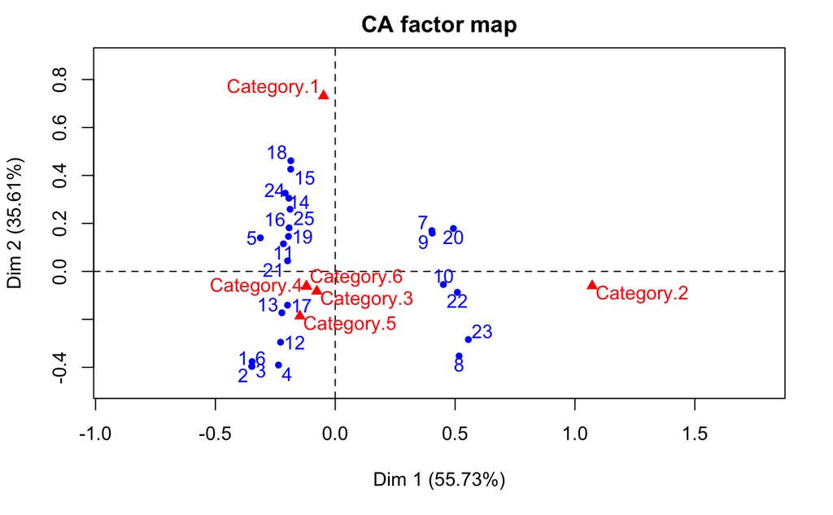

```r
plot(ca_result)
```

##### (c) Analyze the patterns obtained in item 2b. Focus on the total variability, similarities/dissimilarities and the conclusions that can be made from the simultaneous representation of rows and columns. See examples, [4], pp. 92-125.

```r
ca_result
```

```
**Results of the Correspondence Analysis (CA)**
The row variable has  25  categories; the column variable has 6 categories
The chi square of independence between the two variables is equal to 95.63597 (p-value =  0.95053 ).
*The results are available in the following objects:

   name              description
1  "$eig"            "eigenvalues"
2  "$col"            "results for the columns"
3  "$col$coord"      "coord. for the columns"
4  "$col$cos2"       "cos2 for the columns"
5  "$col$contrib"    "contributions of the columns"
6  "$row"            "results for the rows"
7  "$row$coord"      "coord. for the rows"
8  "$row$cos2"       "cos2 for the rows"
9  "$row$contrib"    "contributions of the rows"
10 "$call"           "summary called parameters"
11 "$call$marge.col" "weights of the columns"
12 "$call$marge.row" "weights of the rows"
```

##### (d) Provide the table and graph of eigenvalues, justify the choice of principal components.

```r
round(ca_result$eig, 2)
```

```
      eigenvalue percentage of variance cumulative percentage of variance
dim 1       0.12                  55.73                             55.73
dim 2       0.07                  35.61                             91.34
dim 3       0.01                   6.54                             97.88
dim 4       0.00                   2.12                            100.00
dim 5       0.00                   0.00                            100.00
```

Eigenvalues correspond to the amount of information retained by each axis. Dimensions are ordered decreasingly and listed according to the amount of variance explained in the solution. Dimension 1 explains the most variance in the solution, followed by dimension 2 and so on.

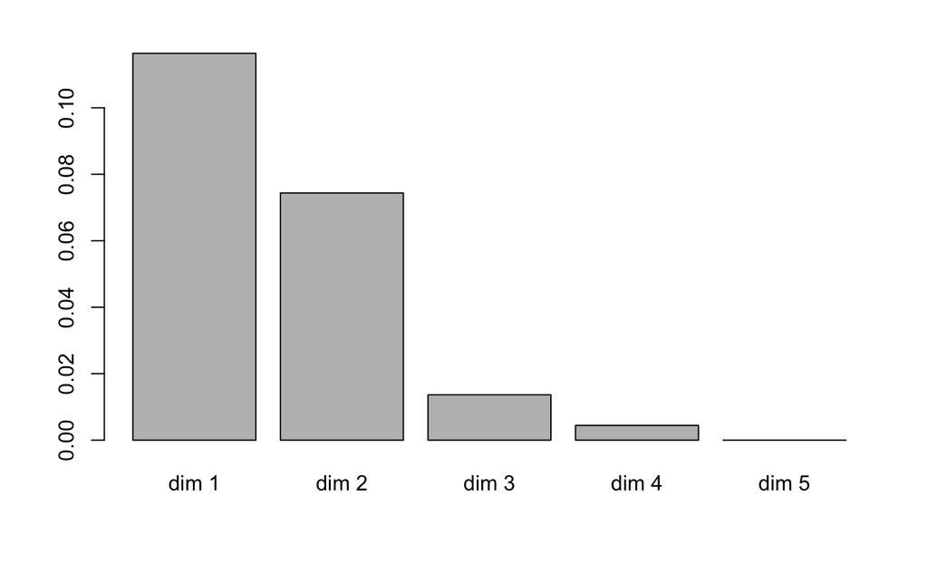

##### (e) Discuss the quality of the CA representation based on cos2 for rows and columns, [4], p.87.

```r
ca_result$col$cos2
```

```
                 Dim 1       Dim 2        Dim 3        Dim 4        Dim 5
Category.1 0.004416227 0.992069397 2.547230e-03 9.671465e-04 2.187172e-12
Category.2 0.996396421 0.003171816 4.236395e-04 8.123432e-06 3.400729e-12
Category.3 0.106712546 0.124405155 7.004183e-01 6.846400e-02 3.751046e-10
Category.4 0.569702558 0.151238249 1.274758e-04 2.788509e-01 8.082025e-05
Category.5 0.254405625 0.407300928 2.844660e-01 5.382746e-02 1.039908e-14
Category.6 0.564757235 0.152802369 5.253608e-05 2.822626e-01 1.252871e-04
```

The result of the CA shows that the the second column (Category. 2) well described by dimension 1 with accuracy 0.99%, but the same dimention doesnot reprecent Category 3 as well. So, the sum of occuracies of categories is slightly equal to one.

```r
ca_result$row$cos2
```

```
       Dim 1      Dim 2        Dim 3        Dim 4        Dim 5
1  0.4341693 0.56212938 0.0035161391 1.844109e-04 7.493268e-07
2  0.4341693 0.56212938 0.0035161391 1.844109e-04 7.493268e-07
3  0.4572390 0.53808251 0.0042065443 4.632749e-04 8.681518e-06
4  0.2668258 0.72661227 0.0063125147 2.400604e-04 9.317945e-06
5  0.7611639 0.15239077 0.0513850090 3.504401e-02 1.633539e-05
6  0.4338357 0.56234827 0.0035273957 2.804496e-04 8.200729e-06
7  0.7842659 0.13938904 0.0616470790 1.469556e-02 2.459353e-06
8  0.6731740 0.31424262 0.0125259598 5.643457e-05 9.894598e-07
9  0.8011836 0.12399434 0.0606642270 1.415783e-02 4.669175e-08
10 0.9413687 0.01389448 0.0407745863 3.962231e-03 4.512125e-10
11 0.6664631 0.18814499 0.0932188965 5.212579e-02 4.725860e-05
12 0.3681485 0.61738520 0.0130983505 1.337747e-03 3.019459e-05
13 0.5968031 0.35952614 0.0343191164 9.306828e-03 4.486112e-05
14 0.2608819 0.63794602 0.0593743065 4.179511e-02 2.684747e-06
15 0.1584835 0.83230515 0.0072777109 1.933655e-03 1.916129e-08
16 0.4636244 0.41219648 0.0811244148 4.305467e-02 2.416874e-08
17 0.4479423 0.22414672 0.1902699749 1.376406e-01 4.467731e-07
18 0.1380438 0.85602211 0.0051774292 7.565882e-04 3.024703e-08
19 0.3878644 0.21642255 0.3938602903 1.851837e-03 9.497291e-07
20 0.8774070 0.11536586 0.0006294728 6.597035e-03 6.330825e-07
21 0.4417235 0.02134307 0.5368947147 3.473419e-05 3.939019e-06
22 0.8966335 0.02644012 0.0754961644 1.429959e-03 2.126022e-07
23 0.7278428 0.19070899 0.0765423264 4.905641e-03 2.824799e-07
24 0.2356678 0.58554541 0.1719421236 6.833555e-03 1.113386e-05
25 0.1267978 0.23974366 0.3141193127 3.193391e-01 1.403532e-07
```

### REFERENCES

[1] Dataset: https://archive.ics.uci.edu/ml/datasets/Tarvel+Review+Ratings# [2] https://www.displayr.com/use-not-use-correspondence-analysis/